# Red Envelop Reverse Engineering

## Notation

- We Assume each event of opening an envelop is **independent**, two different envelop has no correlation between each other.
- We denote the total amount of money of the envelop $M$
- We denote the number of fraction of the envelop $n$ ( at most n people can open the envelop )
- We denote the money each people get if there is no money left in the envelop $m_1,m_2,m_3,\cdots,m_n$ ( by precedence order of time, the first people opens the envelop is $m_1$ and so on ), and $m_i$ is also denote the random variable that the money a person get during the i th pick
- We denote the set of the money every got be $W=\{ m_1,m_2,m_3,\cdots,m_n \}$

## Boundary Cases

The Machanism of the WeChat Red Envelop Garantee that:

- the minimun **unit** of money is 0.01￥, so $\frac{M}{0.01} \ge n$
- We assume **Every** one opens the red envelop will get at least 0.01￥

### Small Boundary Case $\frac{M}{0.01}=n$

I collect three samples for $M=0.03$ and $n=3$, and all get the same result, which is every one will get 0.01. This result consist with that the assumption and common sense that every one will at least get 0.01 yuan so will not be dispointed with get nothing.

```r
M=0.03
n=3
if (M/n<0.01){
  print('Each Person At Least 0.01')
  return( NULL)
}
if (M/0.01=n){
```

```
错误: 意外的'=' in "if (M/0.01="
```

### Small Boundary Case $\frac{M}{0.01}=n+1$

When $n=\frac{M}{0.01}-1$, for example $M=0.03,n=2$ We have 9 tests of this sample, and all get the same result. The last people will get $0.02$, and others $0.01$
$$m_n = 0.02,\ m_1 \cdots m_{n-1} = 0.01$$

```r
if (M/0.01=n+1){
  return( c(rep(0.01, n-1),0.02) )
}
```

### Small Boundary Case $2n>\frac{M}{0.01}>n+1$

By experiment, I used these samples. When three samples of $M=0.07,n=5$ the result is
$$W_1 = [0.01,0.01,0.01,0.01,0.03] \\
W_2 = [0.01,0.01,0.01,0.02,0.02] \\
W_3 = [0.01,0.01,0.01,0.02,0.02] \\$$
And one sample of $M=0.8,n=5$, and the result is:
$$W = [0.01,0.01,0.01,0.02,0.03]$$

And one sample of $M=0.12,n=10$, and the result is:
$$W = [0.01,0.01,0.01,0.01,0.01,0.01,0.01,0.01,0.01,0.03]$$
And one sample of $M=0.13,n=10$, and the result is:
$$W = [0.01,0.01,0.01,0.01,0.01,0.01,0.01,0.02,0.02,0.02]$$
And two sample of $M=0.15,n=10$, and the result is:
$$W = [0.01,0.01,0.01,0.01,0.01,0.01,0.03,0.01,0.01,0.04]\\
W = [0.01,0.01,0.01,0.01,0.01,0.02,0.03,0.01,0.02,0.02]$$

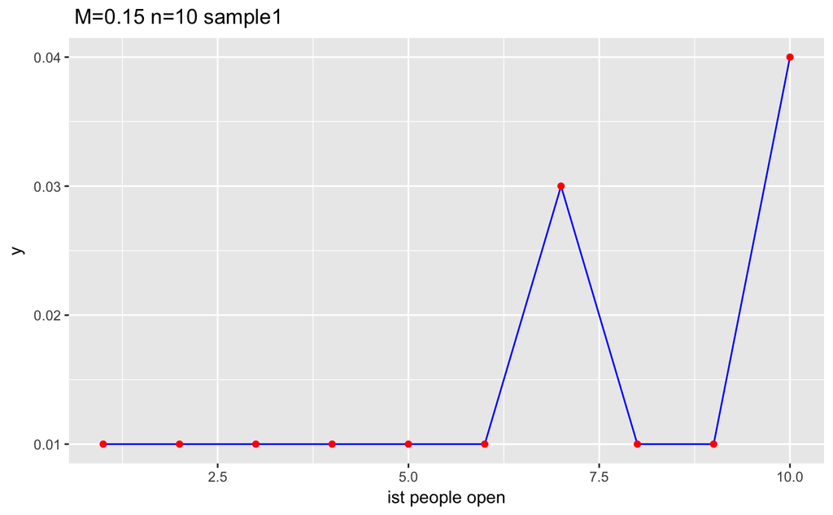

```r
library(ggplot2)
order0 <- c(1:10)
W <- c(0.01,0.01,0.01,0.01,0.01,0.01,0.03,0.01,0.01,0.04)
W1 <- c(0.01,0.01,0.01,0.01,0.01,0.02,0.03,0.01,0.02,0.02)
dt0 <- data.frame(x=order0,y=W,y1=W1)
ggplot(data = dt0,aes(x=x,y=y))+geom_line(colour='blue')+geom_point(colour='red')+labs(title=" M=0.15 n=10 sample1",x="ist people open")
```

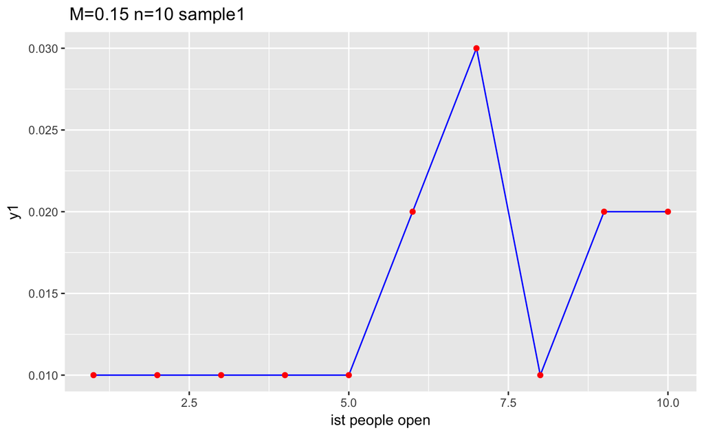

```r
ggplot(data = dt0,aes(x=x,y=y1))+geom_line(colour='blue')+geom_point(colour='red')+labs(title=" M=0.15 n=10 sample1",x="ist people open")
```

Here’s an interesting thing. For a pair of $M,n$ satisfies $2n> \frac{M}{0.01}>n+1$, the first $2n - \frac{M}{0.01}$ people will definately be $0.01$, and the last $\frac{M}{0.01}-n$ people will share the last $2M-0.02n$ ￥

**It shows that when the average money each people get is less than 0.02, first k people will get 0.01 until the average money the last $n-k$ people get is increased to 0.02, and the last $n-k$ people will use different strategy to divide the $0.02\times(n-k)$ money**

So Let’s show the piece of R code

### We can merge the result of these cases and we will get the following code.

```r
M <- 0.19
n <- 10
OpenEnve <- function(M,n){
  if (M/n<0.01){
    print('Each Person At Least 0.01')
    return( NULL)
  }
  else if (M/n<0.02){
    l <- 2*n-M/0.01
    r <- M/0.01-n
    r_money <- 2*M - 0.02*n
    return(c( rep(0.01,l), Level2(r_money,r) ))
  }
  # other Level
}
Level2 <- function(M,n){
  return(...)
}
```

## Dealing With Other Normal Cases

### Experiment A: 50 trials of M=1,n=5 envelop

We define a properly data structure to store the collected data.

```r
library(ggplot2)
dataset <- read.csv('/Users/jeffchiang/Desktop/Dataset.csv')
dataset.5.2 <- dataset[5:54,1:5]
library(DT)
datatable(dataset.5.2)
```

|  | X | X.1 | X.2 | X.3 | X.4 |
| --- | --- | --- | --- | --- | --- |
| 5 | 0.02 | 0.2 | 0.43 | 0.31 | 0.04 |
| 6 | 0.02 | 0.16 | 0.44 | 0.2 | 0.18 |
| 7 | 0.19 | 0.09 | 0.27 | 0.2 | 0.25 |
| 8 | 0.21 | 0.26 | 0.06 | 0.12 | 0.35 |
| 9 | 0.19 | 0.02 | 0.08 | 0.69 | 0.02 |
| 10 | 0.19 | 0.36 | 0.04 | 0.17 | 0.24 |
| 11 | 0.33 | 0.23 | 0.21 | 0.01 | 0.22 |
| 12 | 0.25 | 0.23 | 0.06 | 0.12 | 0.34 |
| 13 | 0.25 | 0.01 | 0.13 | 0.11 | 0.5 |
| 14 | 0.25 | 0.26 | 0.1 | 0.08 | 0.31 |

[output cut: 40 more lines]

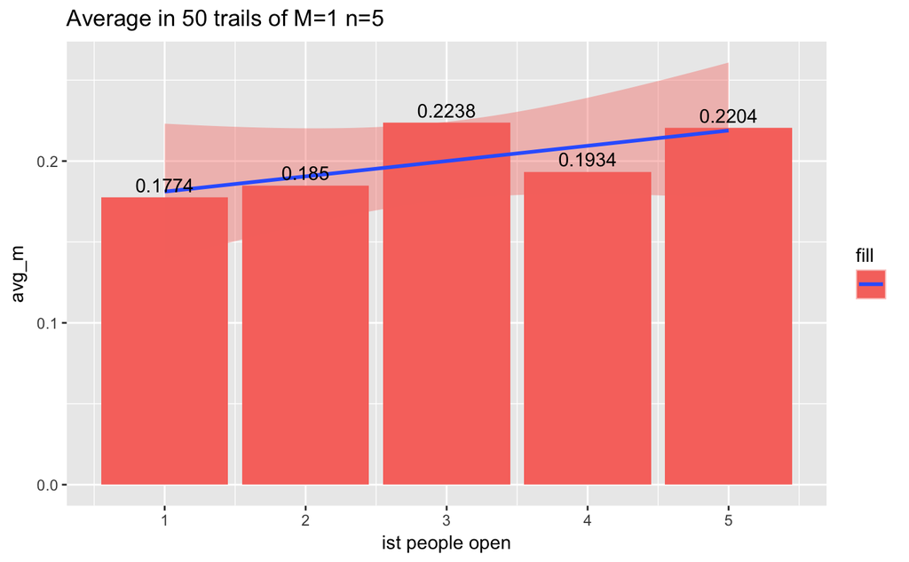

```r
avg_m <- c()
for(i in 1:5){
  avg_m <- c(avg_m,sum(dataset.5.2[i])/50)
}
order1 <- c(1,2,3,4,5)
dt1 <- data.frame(order=order1,avg_m=avg_m)
ggplot(data = dt1, aes(x=order,y=avg_m,fill=''))+geom_bar(stat='identity')+labs(title="Average in 50 trails of M=1 n=5",x="ist people open")+geom_smooth(method = lm)+geom_text(aes(label = avg_m, vjust=-0.4))
```

```r
coeff <- lm(formula = avg_m ~ order1)
```

So the result shows the mean value of the got money along with there order.

Intuitively thinking, the money each people get should be independent with there order to open it, in other words, a good red envelop should tend to divide the money equally for each people, because it’s fair.

In this assumption, we have:

$E(m_1)=E(m_2)=\cdots=E(m_n)=\frac{M}{n}$

Back to this data, the result seems to be close to this assumption $E(m)$, but we need further justification.

Take another look at the data.

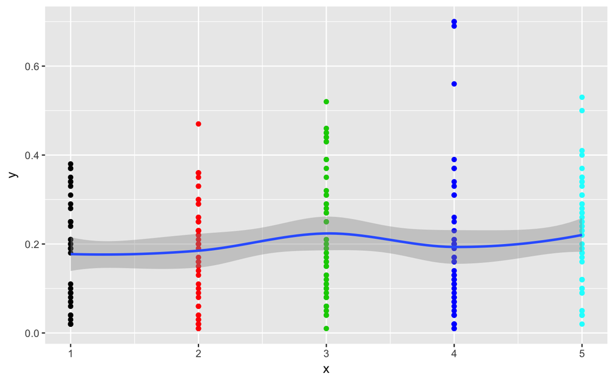

```r
library(ggplot2)
x <- rep(1:5,each = 50)
y <- c(dataset.5.2$X1,dataset.5.2$X2,dataset.5.2$X3,dataset.5.2$X4,dataset.5.2$X5)
dt2 <- data.frame(x=x,y=y)
ggplot()+geom_point(aes(x=x,y=y),colour=x)+geom_smooth(aes(x=x,y=y))
```

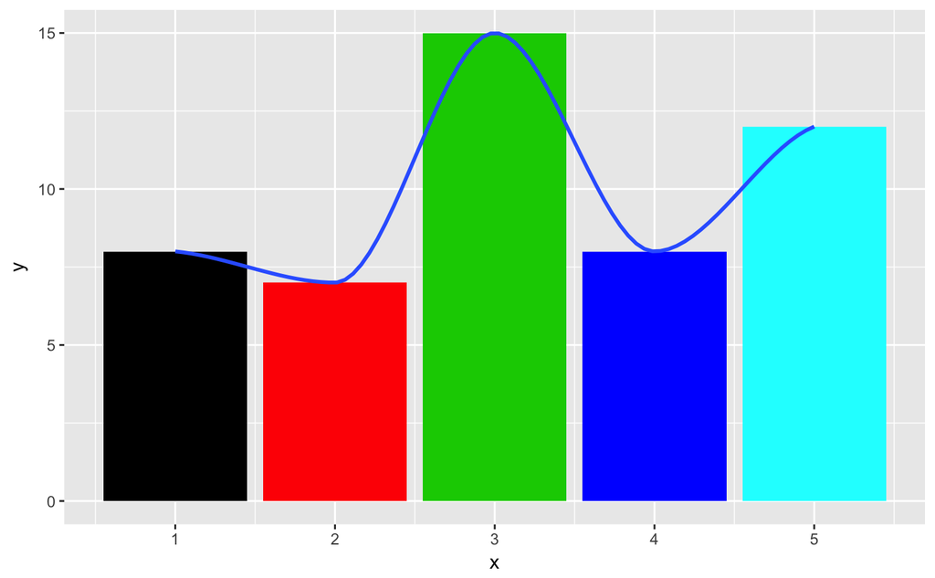

```r
count <- c(0,0,0,0,0)
for(i in 1:50){
  idx <- which(dataset.5.2[i,] == max(dataset.5.2[i,]))
  count[idx] <- count[idx]+1
}
x <- c(1,2,3,4,5)
y <- count
dt2 <- data.frame(x=x,y=y)
ggplot()+geom_bar(aes(x=x,y=y),fill=x,stat = 'identity')+geom_smooth(aes(x=x,y=y))
```

```
Ignoring unknown parameters: binwidth, bins, pad
```

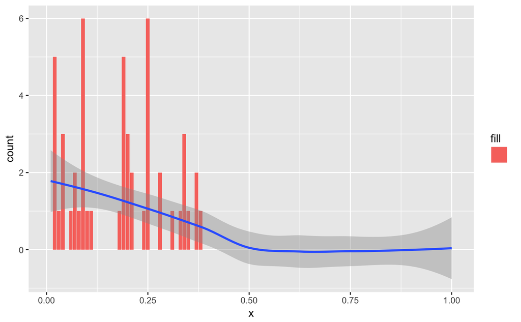

```r
dt2 <- data.frame(x1=dataset.5.2$X1,x2=dataset.5.2$X2,x3=dataset.5.2$X3,x4=dataset.5.2$X4,x5=dataset.5.2$X5)
x <- c(1:100)/100
count <- rep(0,100)
for(i in 1:100){
  idx <- dataset.5.2$X1[i]*100
  count[idx] <- count[idx]+1
}
ggplot()+geom_histogram(stat='identity',binwidth = 0.01, aes(x=x,y=count,fill=''))+geom_smooth(aes(x=x,y=count))
```

```
Ignoring unknown parameters: binwidth, bins, pad
```

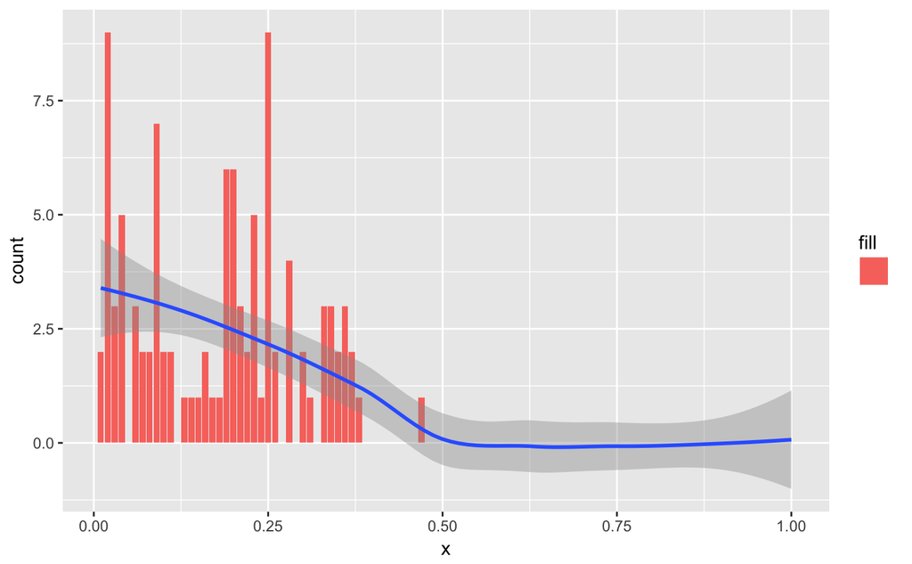

```r
for(i in 1:100){
  idx <- dataset.5.2$X2[i]*100
  count[idx] <- count[idx]+1
}
ggplot()+geom_histogram(stat='identity',binwidth = 0.01, aes(x=x,y=count,fill=''))+geom_smooth(aes(x=x,y=count))
```

```
Ignoring unknown parameters: binwidth, bins, pad
```

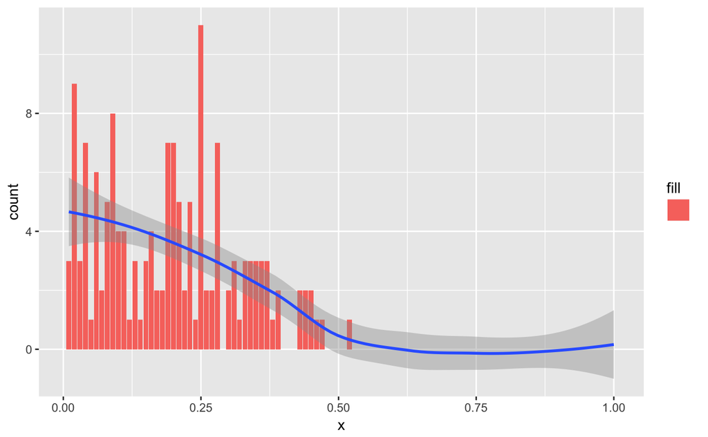

```r
for(i in 1:100){
  idx <- dataset.5.2$X3[i]*100
  count[idx] <- count[idx]+1
}
ggplot()+geom_histogram(stat='identity',binwidth = 0.01, aes(x=x,y=count,fill=''))+geom_smooth(aes(x=x,y=count))
```

```
Ignoring unknown parameters: binwidth, bins, pad
```

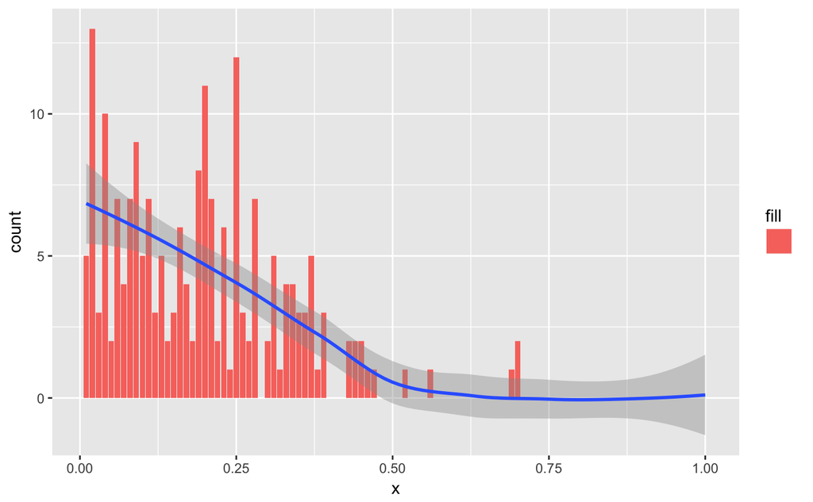

```r
for(i in 1:100){
  idx <- dataset.5.2$X4[i]*100
  count[idx] <- count[idx]+1
}
ggplot()+geom_histogram(stat='identity',binwidth = 0.01, aes(x=x,y=count,fill=''))+geom_smooth(aes(x=x,y=count))
```

```
Ignoring unknown parameters: binwidth, bins, pad
```

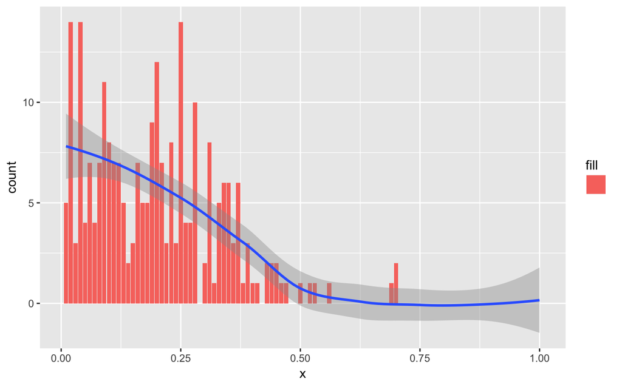

```r
for(i in 1:100){
  idx <- dataset.5.2$X5[i]*100
  count[idx] <- count[idx]+1
}
ggplot()+geom_histogram(stat='identity',binwidth = 0.01, aes(x=x,y=count,fill=''))+geom_smooth(aes(x=x,y=count))
```

Is these facts considences? We have 250 picks in total in this trail so we can be confident to come up with an assumption: there exist a constrain for each pick to ensure that there’s no one can pick a very large number, so other people can get just a little of money. And the constrain for each pick seems different.

### Check the property

```r
check <- 0
for(i in 1:50){
  d <- dataset.5.2[i,]
  m <- 1
  for(j in 1:4){
    if (d[j]<2*m /(6-j)){
      check <- check + 1
      m <- m - d[j]
    }
  }
  check <- check + 1
}
check
```

```
[1] 250
```

### Caculate the Var

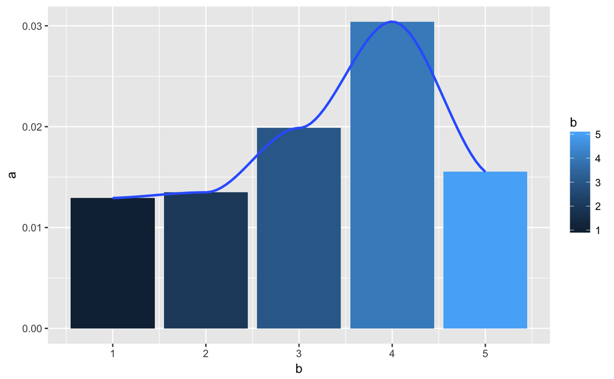

```r
a <- c(var(dataset.5.2$X1),var(dataset.5.2$X2),var(dataset.5.2$X3),var(dataset.5.2$X4),var(dataset.5.2$X5))
b <- 1:5
ggplot()+geom_bar(aes(x=b,y=a,fill=b),stat='identity')+geom_smooth(aes(x=b,y=a))
```

```r
NA
```

```r
M <- 0.19
n <- 10

OpenEnve <- function(M,n){
  if (M/n<0.01){
    print('Each Person At Least 0.01')
    return( NULL)
  }
  else if(M/n==0.01){
    return(rep(0.01,n))
  }
  else if (M/n<=0.02){
    l <- 2*n-M/0.01
    r <- M/0.01-n
    r_money <- 2*M - 0.02*n
    return(c( rep(0.01,l), Level2(r_money,r) ))
  }
  else{
    return(Level2(M,n))
  }
}


Level2 <- function(M,n){
  r_m <- M
  res <- c()
  for(i in 1:n){
    if(i == 1){
      m <- round(runif(1, min = 0.01, max = 2*r_m/n),2)
      res <- c(res, m)
      r_m <- r_m - m
    }else if(i == n){
      res <- c(res, r_m)
    }else{
      m <- round(runif(1, min = 0.01, max = 2*r_m/n),2)
      r_m <- r_m - m
      res <- c(res, m)
    }
  }
  return(res)
}
```